# Koliko nas brzo vrijeme može razdvojiti?

# Molekularna filogenija

Evolucijska stabla možemo dobiti na više načina. Kada vrste uspoređujemo na temelju njihovih morfoloških obilježja kao što su to broj nogu, prisutnost repa ili kandži, dobijemo nešto ovakvo.

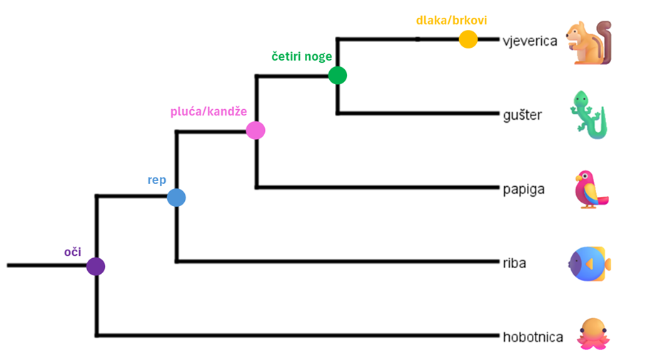

Slika 1. Filogenetsko stablo prema morfološkim karakteristikama

Stablo možemo dobiti i usporedbom molekularnih karakteristika, točnije slijeda slova u genetskom kodu, bilo DNA ili proteina. Tada stablo ima nešto više podataka i izgleda ovako.

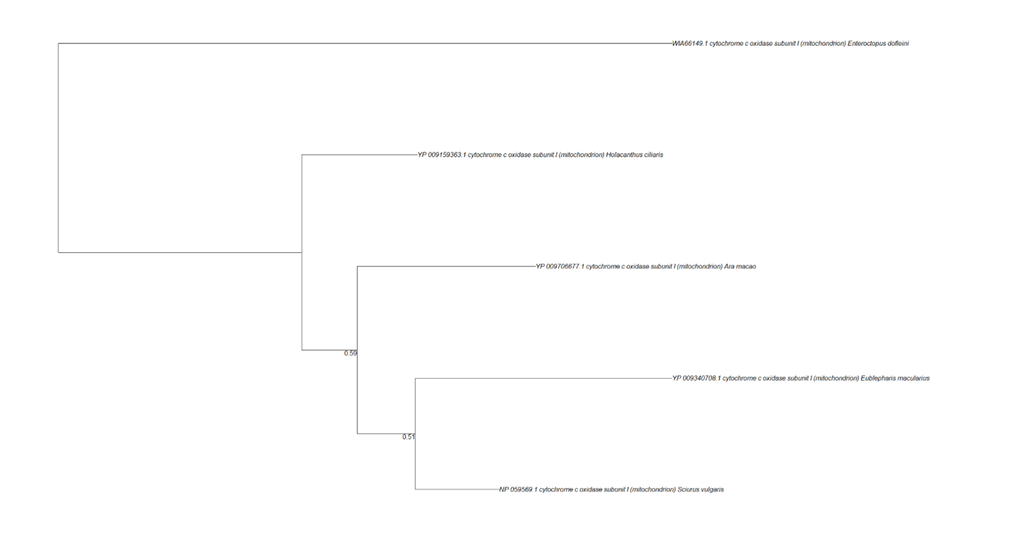

Slika 2. Filogenetsko stablo prema molekularnoj filogeniji

Prema stopi mutacija može se dobiti vremenska udaljenost razdvajanja određenih vrsta – kronogram, ili molekularna različitost – filogram. U oba slučaja imamo uz stablo referentnu skalu (slično mjerilu na geografskoj karti) prema kojoj možemo sa slike iščitati te podatke (molekularnu i vremensku udaljenost) kao razliku u duljini grana.

Zahvaljujući molekularnoj filogenetici danas znamo:

- Mravi beskrilne ose
- Kukci jedna od kopnenih skupina rakova i jedina skupina krilatih rakova
- Mitohondriji alfaproteobakterije koje žive unutar naših stanica
- Tuljani i morski lavovi potekli od pretka sličnog vidrama i kunama
- Biljke kopneni potomci slatkovodnih zelenih algi
- Ptice jedini preživjeli potomci dinosaura te da su time i same dinosauri
- (Plastidi cijanobakterije koje žive unutar eukariotske citoplazme)

## Kako napraviti filogenetsko stablo prema molekularnoj filogenetici?

1. terenski izlazak ⟶ uzorci
2. izolacija DNA ⟶ pročišćavanje i umnožavanje dijelova od interesa
3. sekvenciranje (provjera kvalitete sekvenci)
4. sravnjivanje sekvenci
5. filogenetička analiza ⟶ stablo
6. interpretacija ⟶ pisanje znanstvenog rada

*Mi imamo baze podataka (s milijunima dostupnih sekvenci za skoro sve poznate vrste, najviše za vrste koje znanstvenici koriste u laboratoriju i za čovjeka) iz kojih idemo odmah na sravnjivanje (4. korak).

### Sravnjivanje sekvenci

Za početak pretražimo baze podataka i izaberemo sekvence koje nas zanimaju i za koje vjerujemo da su točne. U određenom programu stavimo sekvence jednu iznad druge i izbacimo redundantne dijelove („viškove”) – ono što je isto u svim ili skoro svim sekvencama (vertikalno, stupci) – vrste možemo razdvojiti samo na temelju njihovih razlika!

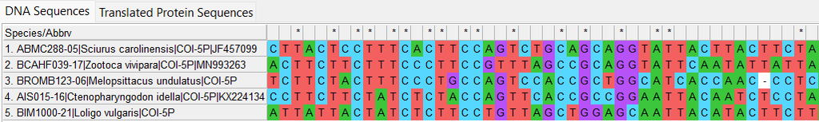

Slika 3. Sravnjivanje sekvenci DNA. Zvjezdicom iznad stupca (*) označeni su dijelovi koji su u svim sekvencama isti i mogu se zanemariti, možemo primijetiti i da su slova u tim stupcima iste boje, ista su.

Moguće je sravniti sekvence aminokiselina (proteinske) ili nukleotidnih baza (DNA). U našem slučaju stablo nije bilo dobro s DNA, već tek kad smo uzeli proteinske sekvence, koje su kod evolucijski udaljenijih vrsta (vjeverica i hobotnica) bolje sačuvane zbog svojih svojstava (proteinske se sekvence manje mijenjaju, funkcionalnost mora biti očuvana, DNA kod je redundantan i mijenja se puno češće i s manjim posljedicama).

Najčešće izaberemo jedan gen, UNILOKUSNA filogenija, iako onda moramo biti svjesni da dobiveno stablo ne mora vrijediti za vrste (filogenija gena nije filogenija vrste, međutim topologija, oblik stabla, koji se opetovano ponavlja kod različitih gena najvjerojatnije točno odražava evoluciju proučavane skupine).

U bazama podataka najčešće su nam dostupni sljedeći geni:

Mitohondrijski geni: **COI ili COXI** (1530 bp; mi smo ga koristili), COII (670 bp), CYTB (1140 bp), ND1(3300–4200 bp), ND4 (1380 bp), ND5 (1810 bp), ND6 (525 bp), ATP6 (680 bp), ATP8 (204 bp), rps3 (1275 bp),matR(1800 bp).

Jezgrini geni: ITS (590 bp), 16S (1550 bp), 18S (1500–2000 bp).

*biramo ovisno o tome što nas zanima, kod stabla mačaka nas zanima evolucija brzine mačaka pa uspoređujemo gene uključene u kretanje, rad mišića.

### Filogenetska analiza

1. Fenetičke metode (*distance-based*, naglasak na razlikama i sličnostima, „udaljenosti”): UPGMA–unweighted pair group method with arithmetic mean Neighbour-joining Minimum evolution
2. Kladističke metode (*character-based*, bitan način evolucije svojstava): MP–Maximum Parsimony (evolucija u najmanji broj koraka je točna) ML–Maximum Likelihood (uz model evolucije) BI–Bayesian Inference (uz početne pretpostavke i dodatne podatke)

### Interpretacija

U biologiji podatke uvijek moramo i potvrditi matematikom, tu granu matematike zovemo statistika. Kod stabla svaki čvor dobije jedan broj, tzv. BOOTSTRAP vrijednost koja predstavlja statističku podržanost, a u analizi vjerujemo čvorovima s velikim brojevima, čvorove s manjim brojevima “urušimo”.

DULJINA GRANA - Duge grane tumače se većom izolacijom od srodnih skupina koje u filogramu imaju kraće grane, tj. manje mutacija ili manje genske promjene u odnosu na srodnike.  
Drugim riječima, životinje koje su se davno u prošlosti međusobno odvojile od zajedničkog pretka, na stablu će biti udaljenije od čvora koji predstavlja tog pretka.

[output not shown]

[output cut: 150 more lines]

[output not shown]

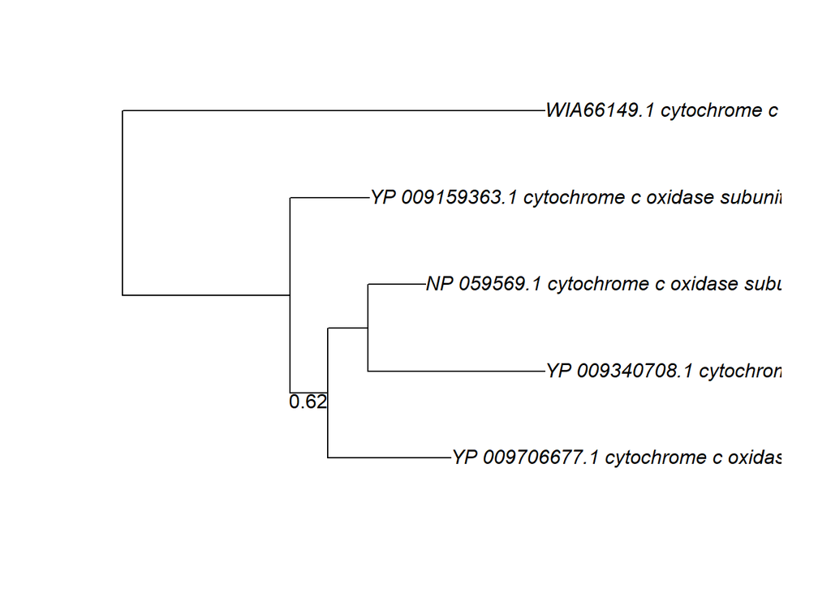